# Análisis Exploratorio de Datos (EDA)

Predicción de Bancarrota Empresarial — Taiwan Economic Journal (1999–2009)

*Laura Rivera · Natalý Cárdenas — Universidad del Norte*

*28 de agosto de 2026*

# Predicción de Quiebra Empresarial - Dataset de Taiwán

**Curso:** Visualización de Datos y Machine Learning

**Autoras:** Laura Rivera y Nataly Cárdenas

**Universidad del Norte**

### Análisis Exploratorio de Datos (EDA)

**Objetivo:** Realizar un análisis exploratorio de datos (EDA) sobre el conjunto de información financiera de empresas taiwanesas con el propósito de comprender su estructura, calidad, distribución y relaciones entre variables, y así preparar una base sólida para el desarrollo de un modelo predictivo de quiebra empresarial.

> **Nota metodológica sobre esta versión:** primero se separan los datos en `train` y `test`, y **todo el análisis exploratorio se hace únicamente sobre `train`**. El conjunto `test` se reserva y no se toca hasta la evaluación final del modelo, para evitar *data leakage* (que información del conjunto de prueba influya en decisiones tomadas antes de entrenar el modelo).

> **Objetivo.** Realizar un análisis exploratorio de datos (EDA) sobre la información financiera de empresas taiwanesas, con el propósito de comprender su estructura, calidad, distribución y relaciones entre variables, y así preparar una base sólida para el desarrollo de un modelo predictivo de quiebra empresarial.

> Primero se separan los datos en `train` y `test`, y **todo el análisis exploratorio se hace únicamente sobre `train`**, para no filtrar información del conjunto de prueba hacia las decisiones tomadas en esta etapa.

## 0.1 Contexto

Antes de entrar en el análisis, esta sección explica el dataset y los conceptos financieros necesarios para entender el resto del libro.

### 0.1.1 ¿Qué es este dataset?

Los datos provienen del **Taiwan Economic Journal** (1999–2009) y contienen indicadores financieros anuales de empresas que cotizan en la Bolsa de Taiwán. Una empresa se marca como **“quebrada” (Bankrupt = 1)** cuando entró en proceso de bancarrota según la normativa de esa bolsa; el resto (Bankrupt = 0) siguió operando con normalidad.

El objetivo es predecir, a partir de razones financieras (ratios), si una empresa está en riesgo de quebrar.

### 0.1.2 ¿Qué es un “ratio” financiero?

Es una relación entre dos cifras del estado financiero de una empresa (por ejemplo, utilidad entre activos) que permite comparar empresas de tamaños distintos en una misma escala. El dataset tiene 95 ratios de este tipo, todos ya calculados.

## 0.2 Carga y preparación inicial

### 0.2.1 Librerías y configuración visual

```r
# Si te falta algún paquete, instálalo una vez con:
# install.packages(c("tidyverse","caret","randomForest","e1071",
#                     "ggcorrplot","scales","knitr","kableExtra","patchwork","car",
#                     "base64enc"))

library(tidyverse)
library(caret)          # createDataPartition, nearZeroVar
library(randomForest)   # Random Forest exploratorio
library(e1071)          # skewness(), kurtosis()
library(ggcorrplot)     # heatmap de correlación
library(scales)         # comma(), percent()
library(knitr)          # kable()
library(kableExtra)     # tablas con mejor formato (scroll_box, etc.)
library(patchwork)      # combinar varios ggplot en una cuadrícula
library(base64enc)      # embeber las 93 gráficas del análisis univariado

RANDOM_STATE <- 42
set.seed(RANDOM_STATE)

# --- Paleta de colores del proyecto (igual a custom.css) ---
COLOR_MAIN   <- "#1B4F72"   # azul oscuro -> gráficos de una sola serie
COLOR_ACCENT <- "#2980B9"   # azul acento -> segundo color de apoyo
COLOR_RISK   <- "#E4572E"   # naranja/rojo -> quiebra / riesgo

TARGET_COLORS <- c("0" = COLOR_MAIN, "1" = COLOR_RISK)
TARGET_LABELS <- c("0" = "No quiebra", "1" = "Quiebra")

# Tema ggplot reutilizable en todo el libro
tema_eda <- theme_minimal(base_size = 12) +
  theme(
    plot.title    = element_text(face = "bold", size = 13, color = COLOR_MAIN, hjust = 0),
    plot.subtitle = element_text(color = "grey40"),
    panel.grid.minor = element_blank(),
    axis.title = element_text(size = 10),
    legend.position = "none"
  )

theme_set(tema_eda)
```

### 0.2.2 Carga del dataset

```r
# Ajusta esta ruta a donde tengas el CSV dentro de tu proyecto
# (recomendado: carpeta data/ dentro del proyecto de RStudio)
df <- read.csv("data/data.csv", check.names = FALSE, stringsAsFactors = FALSE)

# Limpiar nombres de columnas (eliminar espacios extra)
names(df) <- trimws(names(df))

# Verificar la variable objetivo
TARGET <- "Bankrupt?"
if (!(TARGET %in% names(df))) {
  posibles_target <- names(df)[str_detect(str_to_lower(names(df)), "bankrupt")]
  if (length(posibles_target) > 0) {
    TARGET <- posibles_target[1]
    cat("Variable objetivo detectada automáticamente:", TARGET, "\n")
  }
}

cat("Dimensiones del dataset completo:", nrow(df), "filas x", ncol(df), "columnas\n")
```

```
## Dimensiones del dataset completo: 6819 filas x 96 columnas
```

```r
head(df)
```

```
##   Bankrupt? ROA(C) before interest and depreciation before interest ROA(A) before interest and % after tax
## 1         1                                               0.3705943                              0.4243894
## 2         1                                               0.4642909                              0.5382141
## 3         1                                               0.4260713                              0.4990188
## 4         1                                               0.3998440                              0.4512647
## 5         1                                               0.4650222                              0.5384322
## 6         1                                               0.3886803                              0.4151766
##   ROA(B) before interest and depreciation after tax Operating Gross Margin Realized Sales Gross Margin
## 1                                         0.4057498              0.6014572                   0.6014572
## 2                                         0.5167300              0.6102351                   0.6102351
## 3                                         0.4722951              0.6014500                   0.6013635
## 4                                         0.4577333              0.5835411                   0.5835411
## 5                                         0.5222978              0.5987835                   0.5987835
## 6                                         0.4191338              0.5901714                   0.5902507
##   Operating Profit Rate Pre-tax net Interest Rate After-tax net Interest Rate Non-industry income and expenditure/revenue
```

[output cut: 160 more lines]

```r
tail(df)
```

```
##      Bankrupt? ROA(C) before interest and depreciation before interest ROA(A) before interest and % after tax
## 6814         0                                               0.4775996                              0.5311273
## 6815         0                                               0.4936869                              0.5394679
## 6816         0                                               0.4751621                              0.5382686
## 6817         0                                               0.4727246                              0.5337440
## 6818         0                                               0.5062643                              0.5599106
## 6819         0                                               0.4930532                              0.5701047
##      ROA(B) before interest and depreciation after tax Operating Gross Margin Realized Sales Gross Margin
## 6814                                         0.5260988              0.5958287                   0.5958575
## 6815                                         0.5432304              0.6044552                   0.6044624
## 6816                                         0.5241715              0.5983078                   0.5983078
## 6817                                         0.5206381              0.6104441                   0.6102135
## 6818                                         0.5540446              0.6078496                   0.6078496
## 6819                                         0.5495476              0.6274089                   0.6274089
##      Operating Profit Rate Pre-tax net Interest Rate After-tax net Interest Rate
```

[output cut: 167 more lines]

```r
cat("Columnas del dataset:\n")
```

```
## Columnas del dataset:
```

```r
print(names(df))
```

```
##  [1] "Bankrupt?"                                               "ROA(C) before interest and depreciation before interest"
##  [3] "ROA(A) before interest and % after tax"                  "ROA(B) before interest and depreciation after tax"
##  [5] "Operating Gross Margin"                                  "Realized Sales Gross Margin"
##  [7] "Operating Profit Rate"                                   "Pre-tax net Interest Rate"
##  [9] "After-tax net Interest Rate"                             "Non-industry income and expenditure/revenue"
## [11] "Continuous interest rate (after tax)"                    "Operating Expense Rate"
## [13] "Research and development expense rate"                   "Cash flow rate"
## [15] "Interest-bearing debt interest rate"                     "Tax rate (A)"
## [17] "Net Value Per Share (B)"                                 "Net Value Per Share (A)"
## [19] "Net Value Per Share (C)"                                 "Persistent EPS in the Last Four Seasons"
## [21] "Cash Flow Per Share"                                     "Revenue Per Share (Yuan ¥)"
## [23] "Operating Profit Per Share (Yuan ¥)"                     "Per Share Net profit before tax (Yuan ¥)"
## [25] "Realized Sales Gross Profit Growth Rate"                 "Operating Profit Growth Rate"
## [27] "After-tax Net Profit Growth Rate"                        "Regular Net Profit Growth Rate"
## [29] "Continuous Net Profit Growth Rate"                       "Total Asset Growth Rate"
```

[output cut: 33 more lines]

```r
str(df)
```

```
## 'data.frame':    6819 obs. of  96 variables:
##  $ Bankrupt?                                              : int  1 1 1 1 1 1 0 0 0 0 ...
##  $ ROA(C) before interest and depreciation before interest: num  0.371 0.464 0.426 0.4 0.465 ...
##  $ ROA(A) before interest and % after tax                 : num  0.424 0.538 0.499 0.451 0.538 ...
##  $ ROA(B) before interest and depreciation after tax      : num  0.406 0.517 0.472 0.458 0.522 ...
##  $ Operating Gross Margin                                 : num  0.601 0.61 0.601 0.584 0.599 ...
##  $ Realized Sales Gross Margin                            : num  0.601 0.61 0.601 0.584 0.599 ...
##  $ Operating Profit Rate                                  : num  0.999 0.999 0.999 0.999 0.999 ...
##  $ Pre-tax net Interest Rate                              : num  0.797 0.797 0.796 0.797 0.797 ...
##  $ After-tax net Interest Rate                            : num  0.809 0.809 0.808 0.809 0.809 ...
##  $ Non-industry income and expenditure/revenue            : num  0.303 0.304 0.302 0.303 0.303 ...
##  $ Continuous interest rate (after tax)                   : num  0.781 0.782 0.78 0.781 0.782 ...
##  $ Operating Expense Rate                                 : num  1.26e-04 2.90e-04 2.36e-04 1.08e-04 7.89e+09 ...
##  $ Research and development expense rate                  : num  0.00 0.00 2.55e+07 0.00 0.00 0.00 7.30e+08 5.09e+07 0.00 0.00 ...
##  $ Cash flow rate                                         : num  0.458 0.462 0.459 0.466 0.463 ...
```

[output cut: 82 more lines]

> El dataset tiene 6.819 empresas y 96 columnas (95 ratios financieros + la variable objetivo). Casi todas las columnas son numéricas (`double`), salvo `Bankrupt?`, `Liability-Assets Flag` y `Net Income Flag`, que están guardadas como enteros pero en realidad son variables categóricas binarias (0/1), no cantidades.

### 0.2.3 Tipo de problema, target y features

```r
cat_vars <- c("Liability-Assets Flag", "Net Income Flag")
num_vars <- setdiff(names(df), c(cat_vars, TARGET))

cat("Variable objetivo:", TARGET, "\n")
```

```
## Variable objetivo: Bankrupt?
```

```r
cat("Valores únicos del target:", paste(sort(unique(df[[TARGET]])), collapse = ", "), "\n")
```

```
## Valores únicos del target: 0, 1
```

```r
cat("\nTipo de problema: CLASIFICACIÓN BINARIA\n")
```

```
##
## Tipo de problema: CLASIFICACIÓN BINARIA
```

```r
cat("(el target solo toma dos valores: 0 = no quebró, 1 = quebró)\n")
```

```
## (el target solo toma dos valores: 0 = no quebró, 1 = quebró)
```

```r
cat("\nVariables predictoras numéricas:", length(num_vars), "\n")
```

```
##
## Variables predictoras numéricas: 93
```

```r
cat("Variables predictoras categóricas (flags 0/1):", length(cat_vars),
    "->", paste(cat_vars, collapse = ", "), "\n")
```

```
## Variables predictoras categóricas (flags 0/1): 2 -> Liability-Assets Flag, Net Income Flag
```

### 0.2.4 División train / test

Antes de explorar los datos a fondo, separamos un conjunto de prueba (`test`) que se reserva para la evaluación final del modelo. **A partir de aquí, todo el EDA se hace usando exclusivamente `train`.** El conjunto `test` no se grafica, no se describe y no influye en ninguna decisión de este análisis.

```r
set.seed(RANDOM_STATE)

idx_train <- createDataPartition(df[[TARGET]], p = 0.8, list = FALSE)
train_df  <- df[idx_train, ]
test_df   <- df[-idx_train, ]

cat(sprintf("Observaciones en train: %d (%.1f%%)\n",
            nrow(train_df), nrow(train_df) / nrow(df) * 100))
```

```
## Observaciones en train: 5456 (80.0%)
```

```r
cat(sprintf("Observaciones en test:  %d (%.1f%%)\n",
            nrow(test_df), nrow(test_df) / nrow(df) * 100))
```

```
## Observaciones en test:  1363 (20.0%)
```

```r
cat("\nProporción de la clase 'Quiebra' en cada conjunto",
    "(debe ser similar por la estratificación):\n")
```

```
##
## Proporción de la clase 'Quiebra' en cada conjunto (debe ser similar por la estratificación):
```

```r
cat(sprintf("  Train: %.2f%%\n", mean(train_df[[TARGET]]) * 100))
```

```
##   Train: 3.43%
```

```r
cat(sprintf("  Test:  %.2f%%\n", mean(test_df[[TARGET]]) * 100))
```

```
##   Test:  2.42%
```

### 0.2.5 Persistencia del split para las etapas posteriores

Guardamos `train_df` y `test_df` en disco para que la etapa de modelado use exactamente la misma partición que se usó en este EDA, sin necesidad de recalcularla.

```r
dir.create("data/processed", showWarnings = FALSE, recursive = TRUE)
saveRDS(
  list(train = train_df, test = test_df, target = TARGET,
       num_vars = num_vars, cat_vars = cat_vars),
  file = "data/processed/train_test_split.rds"
)
```

## 0.3 Calidad de los datos (sobre `train`)

### 0.3.1 Valores nulos

```r
nulos <- colSums(is.na(train_df))
nulos <- nulos[nulos > 0]

if (length(nulos) == 0) {
  cat("No se encontraron valores nulos en train.\n")
} else {
  cat("Se encontraron", length(nulos), "columnas con valores nulos:\n")
  print(nulos)
}
```

```
## No se encontraron valores nulos en train.
```

Ninguna empresa de `train` tiene información faltante en sus estados financieros.

### 0.3.2 Filas duplicadas

```r
duplicados <- sum(duplicated(train_df))
cat("Filas duplicadas en train:", duplicados, "\n")
```

```
## Filas duplicadas en train: 0
```

No hay filas repetidas en `train`, así que no es necesario eliminar duplicados.

### 0.3.3 Variables categóricas y cardinalidad

```r
for (c in cat_vars) {
  print(table(train_df[[c]]))
  cat("Cardinalidad:", length(unique(train_df[[c]])), "valores únicos\n\n")
}
```

```
##
##    0    1
## 5449    7
## Cardinalidad: 2 valores únicos
##
##
##    1
## 5456
## Cardinalidad: 1 valores únicos
```

> `Net Income Flag` vale 1 para prácticamente el 100% de las empresas en `train`, es decir, no importa si una empresa quebró o no, casi siempre tiene el mismo valor (1). Por lo tanto, es una variable (casi) constante y sería una candidata clara para eliminar antes del modelado. `Liability-Assets Flag` sí varía, aunque muy poco. Vale la pena revisarla más adelante junto al target, en la sección de análisis bivariado.

## 0.4 Análisis univariado (sobre `train`)

### 0.4.1 Estadísticas descriptivas

```r
# Réplica de generar_estadisticas_univariadas() del notebook: N, media, DS,
# curtosis, mediana, mínimo, máximo, Q1, Q3 e IQR para las 93 variables
# numéricas completas (no solo una muestra), dentro de un contenedor con
# scroll para mantenerlas todas disponibles sin romper el flujo del libro.
generar_estadisticas_univariadas <- function(df, variables) {
  map_dfr(variables, function(var) {
    serie <- df[[var]]
    serie <- serie[!is.na(serie)]
    q <- quantile(serie, c(0.25, 0.75))
    tibble(
      Variable = var,
      N        = length(serie),
      Media    = mean(serie),
      DS       = sd(serie),
      Curtosis = e1071::kurtosis(serie, type = 2),
      Mediana  = median(serie),
      Minimo   = min(serie),
      Maximo   = max(serie),
      Q1       = q[[1]],
      Q3       = q[[2]],
      IQR      = q[[2]] - q[[1]]
    )
  })
}

df_stats_num <- generar_estadisticas_univariadas(train_df, num_vars)

df_stats_num %>%
  kable(digits = c(0, 0, 2, 2, 2, 2, 2, 2, 2, 2, 2),
        col.names = c("Variable", "N", "Media", "DS", "Curtosis", "Mediana",
                       "Mínimo", "Máximo", "Q1", "Q3", "IQR"),
        caption = "Estadísticas descriptivas de las 93 variables numéricas (train)") %>%
  kable_styling(bootstrap_options = c("striped", "hover", "condensed"),
                full_width = FALSE, font_size = 12) %>%
  scroll_box(height = "420px")
```

Table 1: Table 2: Estadísticas descriptivas de las 93 variables numéricas (train)

| Variable | N | Media | DS | Curtosis | Mediana | Mínimo | Máximo | Q1 | Q3 | IQR |
| --- | --- | --- | --- | --- | --- | --- | --- | --- | --- | --- |
| ROA(C) before interest and depreciation before interest | 5456 | 5.100000e-01 | 6.000000e-02 | 6.48 | 5.00e-01 | 0.00 | 9.70e-01 | 4.80e-01 | 5.4000e-01 | 6.0000e-02 |
| ROA(A) before interest and % after tax | 5456 | 5.600000e-01 | 7.000000e-02 | 9.08 | 5.60e-01 | 0.00 | 1.00e+00 | 5.40e-01 | 5.9000e-01 | 5.0000e-02 |
| ROA(B) before interest and depreciation after tax | 5456 | 5.500000e-01 | 6.000000e-02 | 8.36 | 5.50e-01 | 0.00 | 1.00e+00 | 5.30e-01 | 5.8000e-01 | 6.0000e-02 |
| Operating Gross Margin | 5456 | 6.100000e-01 | 2.000000e-02 | 377.59 | 6.10e-01 | 0.00 | 1.00e+00 | 6.00e-01 | 6.1000e-01 | 1.0000e-02 |
| Realized Sales Gross Margin | 5456 | 6.100000e-01 | 2.000000e-02 | 378.72 | 6.10e-01 | 0.00 | 1.00e+00 | 6.00e-01 | 6.1000e-01 | 1.0000e-02 |
| Operating Profit Rate | 5456 | 1.000000e+00 | 1.000000e-02 | 5041.16 | 1.00e+00 | 0.61 | 1.00e+00 | 1.00e+00 | 1.0000e+00 | 0.0000e+00 |
| Pre-tax net Interest Rate | 5456 | 8.000000e-01 | 1.000000e-02 | 3772.15 | 8.00e-01 | 0.16 | 1.00e+00 | 8.00e-01 | 8.0000e-01 | 0.0000e+00 |
| After-tax net Interest Rate | 5456 | 8.100000e-01 | 1.000000e-02 | 4356.85 | 8.10e-01 | 0.00 | 1.00e+00 | 8.10e-01 | 8.1000e-01 | 0.0000e+00 |
| Non-industry income and expenditure/revenue | 5456 | 3.000000e-01 | 1.000000e-02 | 1881.14 | 3.00e-01 | 0.00 | 7.30e-01 | 3.00e-01 | 3.0000e-01 | 0.0000e+00 |
| Continuous interest rate (after tax) | 5456 | 7.800000e-01 | 1.000000e-02 | 4160.36 | 7.80e-01 | 0.13 | 1.00e+00 | 7.80e-01 | 7.8000e-01 | 0.0000e+00 |
| Operating Expense Rate | 5456 | 2.013091e+09 | 3.252014e+09 | -0.11 | 0.00e+00 | 0.00 | 9.99e+09 | 0.00e+00 | 4.1325e+09 | 4.1325e+09 |
| Research and development expense rate | 5456 | 1.977043e+09 | 2.628144e+09 | 0.55 | 5.43e+08 | 0.00 | 9.98e+09 | 0.00e+00 | 3.4600e+09 | 3.4600e+09 |
| Cash flow rate | 5456 | 4.700000e-01 | 2.000000e-02 | 262.45 | 4.70e-01 | 0.00 | 1.00e+00 | 4.60e-01 | 4.7000e-01 | 1.0000e-02 |
| Interest-bearing debt interest rate | 5456 | 1.739644e+07 | 1.116564e+08 | 47.35 | 0.00e+00 | 0.00 | 9.90e+08 | 0.00e+00 | 0.0000e+00 | 0.0000e+00 |
| Tax rate (A) | 5456 | 1.100000e-01 | 1.400000e-01 | 5.87 | 7.00e-02 | 0.00 | 1.00e+00 | 0.00e+00 | 2.1000e-01 | 2.1000e-01 |
| Net Value Per Share (B) | 5456 | 1.900000e-01 | 3.000000e-02 | 79.43 | 1.80e-01 | 0.00 | 1.00e+00 | 1.70e-01 | 2.0000e-01 | 3.0000e-02 |
| Net Value Per Share (A) | 5456 | 1.900000e-01 | 3.000000e-02 | 78.56 | 1.80e-01 | 0.00 | 1.00e+00 | 1.70e-01 | 2.0000e-01 | 3.0000e-02 |
| Net Value Per Share (C) | 5456 | 1.900000e-01 | 3.000000e-02 | 78.47 | 1.80e-01 | 0.00 | 1.00e+00 | 1.70e-01 | 2.0000e-01 | 3.0000e-02 |
| Persistent EPS in the Last Four Seasons | 5456 | 2.300000e-01 | 3.000000e-02 | 52.87 | 2.20e-01 | 0.08 | 7.80e-01 | 2.10e-01 | 2.4000e-01 | 2.0000e-02 |
| Cash Flow Per Share | 5456 | 3.200000e-01 | 2.000000e-02 | 433.50 | 3.20e-01 | 0.13 | 1.00e+00 | 3.20e-01 | 3.3000e-01 | 1.0000e-02 |
| Revenue Per Share (Yuan ¥) | 5456 | 1.660557e+06 | 5.780234e+07 | 1701.87 | 3.00e-02 | 0.00 | 3.02e+09 | 2.00e-02 | 5.0000e-02 | 3.0000e-02 |
| Operating Profit Per Share (Yuan ¥) | 5456 | 1.100000e-01 | 3.000000e-02 | 92.73 | 1.00e-01 | 0.00 | 7.40e-01 | 1.00e-01 | 1.2000e-01 | 2.0000e-02 |
| Per Share Net profit before tax (Yuan ¥) | 5456 | 1.800000e-01 | 3.000000e-02 | 65.71 | 1.80e-01 | 0.05 | 7.90e-01 | 1.70e-01 | 1.9000e-01 | 2.0000e-02 |
| Realized Sales Gross Profit Growth Rate | 5456 | 2.000000e-02 | 1.000000e-02 | 5053.61 | 2.00e-02 | 0.00 | 1.00e+00 | 2.00e-02 | 2.0000e-02 | 0.0000e+00 |
| Operating Profit Growth Rate | 5456 | 8.500000e-01 | 1.000000e-02 | 4836.49 | 8.50e-01 | 0.00 | 9.30e-01 | 8.50e-01 | 8.5000e-01 | 0.0000e+00 |
| After-tax Net Profit Growth Rate | 5456 | 6.900000e-01 | 1.000000e-02 | 1438.63 | 6.90e-01 | 0.00 | 1.00e+00 | 6.90e-01 | 6.9000e-01 | 0.0000e+00 |
| Regular Net Profit Growth Rate | 5456 | 6.900000e-01 | 1.000000e-02 | 1422.02 | 6.90e-01 | 0.00 | 1.00e+00 | 6.90e-01 | 6.9000e-01 | 0.0000e+00 |
| Continuous Net Profit Growth Rate | 5456 | 2.200000e-01 | 1.000000e-02 | 4358.92 | 2.20e-01 | 0.00 | 1.00e+00 | 2.20e-01 | 2.2000e-01 | 0.0000e+00 |
| Total Asset Growth Rate | 5456 | 5.528156e+09 | 2.895923e+09 | -0.39 | 6.42e+09 | 0.00 | 9.98e+09 | 4.88e+09 | 7.4000e+09 | 2.5200e+09 |
| Net Value Growth Rate | 5456 | 1.957478e+06 | 1.276241e+08 | 5236.67 | 0.00e+00 | 0.00 | 9.33e+09 | 0.00e+00 | 0.0000e+00 | 0.0000e+00 |

[output cut: 63 more lines]

Las escalas son muy distintas entre variables (algunas van de 0 a 1, otras tienen valores en miles). Esto ya nos dice que, para cualquier modelo sensible a la escala (como regresión logística, SVM o PCA), va a hacer falta estandarizar las variables en el pipeline de preprocesamiento.

### 0.4.2 Variables con varianza cercana a cero

```r
varianzas  <- sapply(train_df[num_vars], var, na.rm = TRUE)
vars_bajas <- varianzas[varianzas < 1e-6]

cat("Variables con varianza baja:", length(vars_bajas), "\n")
```

```
## Variables con varianza baja: 1
```

```r
if (length(vars_bajas) > 0) {
  print(vars_bajas)
} else {
  cat("Ninguna variable numérica tiene varianza cercana a cero en train.\n")
}
```

```
## Total income/Total expense
##               2.229908e-07
```

### 0.4.3 Gráficas

Cada una de las 93 variables numéricas se resume en una figura con dos paneles (histograma + densidad, y boxplot), acompañada de una interpretación generada automáticamente a partir de su sesgo, media, mediana y curtosis — igual que en el notebook. Los 93 bloques se acumulan dentro de un único contenedor con scroll interno, en vez de mostrarse uno detrás de otro.

```r
dir_imgs_univ <- file.path(tempdir(), "univariado_imgs")
dir.create(dir_imgs_univ, showWarnings = FALSE)

generar_bloque_univariado <- function(var) {
  serie <- train_df[[var]]
  serie <- serie[!is.na(serie)]
  media_v   <- mean(serie)
  mediana_v <- median(serie)
  skew_v    <- e1071::skewness(serie, type = 2)
  kurt_v    <- e1071::kurtosis(serie, type = 2)

  p_dens <- ggplot(train_df, aes(x = .data[[var]])) +
    geom_histogram(aes(y = after_stat(density)), bins = 30,
                    fill = COLOR_MAIN, color = "white", alpha = 0.85) +
    geom_density(color = COLOR_RISK, linewidth = 1.0) +
    geom_vline(xintercept = media_v, color = COLOR_RISK, linetype = "dashed",
               linewidth = 0.7) +
    geom_vline(xintercept = mediana_v, color = COLOR_ACCENT, linetype = "dotted",
               linewidth = 0.9) +
    labs(title = "Distribución (histograma + densidad)", x = var, y = "Densidad") +
    tema_eda +
    theme(plot.title = element_text(size = 10))

  p_box <- ggplot(train_df, aes(x = "", y = .data[[var]])) +
    geom_boxplot(fill = COLOR_MAIN, color = COLOR_MAIN, width = 0.35,
                 outlier.color = COLOR_RISK, outlier.alpha = 0.5, outlier.size = 1.5) +
    labs(title = "Boxplot", x = NULL, y = var) +
    tema_eda +
    theme(plot.title = element_text(size = 10))

  archivo <- file.path(dir_imgs_univ, paste0(make.names(var), ".png"))
  ggsave(archivo, p_dens + p_box, width = 7.5, height = 2.8, dpi = 72)
  imagen_b64 <- base64enc::base64encode(archivo)

  asimetria_desc <- if (abs(skew_v) < 0.5) {
    "una distribución relativamente simétrica"
  } else if (skew_v >= 0.5) {
    "un marcado sesgo a la derecha (asimetría positiva)"
  } else {
    "un marcado sesgo a la izquierda (asimetría negativa)"
  }

  texto_interpretacion <- sprintf(
    "El histograma de <b>%s</b> muestra %s, con una media de <b>%.4f</b> y una mediana de <b>%.4f</b>. La curtosis observada de <b>%.2f</b> indica la concentraci\u00f3n de observaciones alrededor de la zona central, con posibles valores at\u00edpicos en las colas. Esta morfolog\u00eda sugiere una alta homogeneidad en el grueso de las empresas analizadas, con comportamientos extremos puntuales a monitorear en el preprocesamiento.",
    var, asimetria_desc, media_v, mediana_v, kurt_v
  )

  # IMPORTANTE: el HTML se arma en UNA sola línea por etiqueta y sin sangría.
  # Pandoc interpreta las líneas indentadas con 4+ espacios (tras una línea en
  # blanco) como un bloque de código literal en vez de HTML crudo -- por eso
  # el bloque anterior salía como texto plano en vez de renderizarse.
  paste0(
    '<div style="background-color:#FFFFFF;border:1px solid #D8D3C7;border-radius:8px;padding:16px 18px;margin-bottom:18px;font-family:\'Source Sans 3\',sans-serif;">',
    '<h4 style="color:#1F2D3D;margin:0 0 10px 0;font-size:14px;font-weight:700;">', var, '</h4>',
    '<div style="text-align:center;margin-bottom:12px;">',
    '<img src="data:…', imagen_b64, '" style="max-width:100%;height:auto;border-radius:4px;">',
    '</div>',
    '<p style="margin:0;color:#5B5F66;font-size:13px;line-height:1.6;border-left:4px solid #7A2E2E;background-color:#F7F6F3;padding:10px 14px;border-radius:4px;">',
    texto_interpretacion,
    '</p>',
    '</div>'
  )
}

# Se libera memoria cada 15 variables para evitar que el render se quede
# sin RAM al acumular 93 gráficas + sus imágenes en memoria.
bloques_univariado <- character(length(num_vars))
for (i in seq_along(num_vars)) {
  bloques_univariado[i] <- generar_bloque_univariado(num_vars[i])
  if (i %% 15 == 0) invisible(gc(full = TRUE))
}

cat(
  paste0(
    '<div style="max-height:640px;overflow-y:auto;border:1px solid #D8D3C7;border-radius:8px;padding:14px;background-color:#F7F6F3;">',
    paste(bloques_univariado, collapse = ""),
    '</div>'
  )
)
```

#### ROA(C) before interest and depreciation before interest

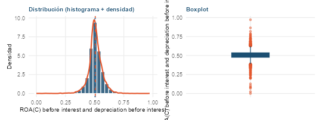

El histograma de **ROA(C) before interest and depreciation before interest** muestra una distribución relativamente simétrica, con una media de **0.5053** y una mediana de **0.5032**. La curtosis observada de **6.48** indica la concentración de observaciones alrededor de la zona central, con posibles valores atípicos en las colas. Esta morfología sugiere una alta homogeneidad en el grueso de las empresas analizadas, con comportamientos extremos puntuales a monitorear en el preprocesamiento.

#### ROA(A) before interest and % after tax

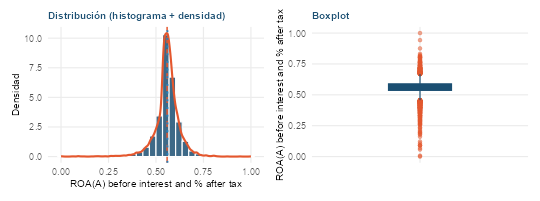

El histograma de **ROA(A) before interest and % after tax** muestra un marcado sesgo a la izquierda (asimetría negativa), con una media de **0.5586** y una mediana de **0.5602**. La curtosis observada de **9.08** indica la concentración de observaciones alrededor de la zona central, con posibles valores atípicos en las colas. Esta morfología sugiere una alta homogeneidad en el grueso de las empresas analizadas, con comportamientos extremos puntuales a monitorear en el preprocesamiento.

#### ROA(B) before interest and depreciation after tax

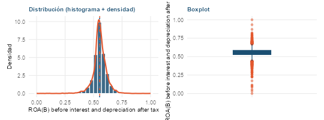

El histograma de **ROA(B) before interest and depreciation after tax** muestra un marcado sesgo a la izquierda (asimetría negativa), con una media de **0.5537** y una mediana de **0.5526**. La curtosis observada de **8.36** indica la concentración de observaciones alrededor de la zona central, con posibles valores atípicos en las colas. Esta morfología sugiere una alta homogeneidad en el grueso de las empresas analizadas, con comportamientos extremos puntuales a monitorear en el preprocesamiento.

#### Operating Gross Margin

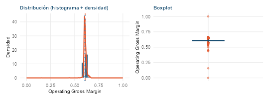

El histograma de **Operating Gross Margin** muestra un marcado sesgo a la izquierda (asimetría negativa), con una media de **0.6080** y una mediana de **0.6061**. La curtosis observada de **377.59** indica la concentración de observaciones alrededor de la zona central, con posibles valores atípicos en las colas. Esta morfología sugiere una alta homogeneidad en el grueso de las empresas analizadas, con comportamientos extremos puntuales a monitorear en el preprocesamiento.

#### Realized Sales Gross Margin

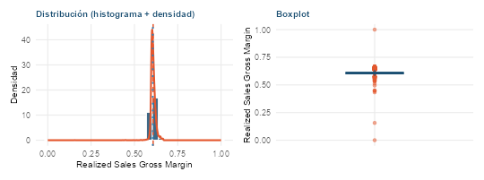

El histograma de **Realized Sales Gross Margin** muestra un marcado sesgo a la izquierda (asimetría negativa), con una media de **0.6080** y una mediana de **0.6060**. La curtosis observada de **378.72** indica la concentración de observaciones alrededor de la zona central, con posibles valores atípicos en las colas. Esta morfología sugiere una alta homogeneidad en el grueso de las empresas analizadas, con comportamientos extremos puntuales a monitorear en el preprocesamiento.

#### Operating Profit Rate

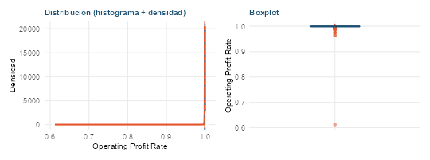

El histograma de **Operating Profit Rate** muestra un marcado sesgo a la izquierda (asimetría negativa), con una media de **0.9989** y una mediana de **0.9990**. La curtosis observada de **5041.16** indica la concentración de observaciones alrededor de la zona central, con posibles valores atípicos en las colas. Esta morfología sugiere una alta homogeneidad en el grueso de las empresas analizadas, con comportamientos extremos puntuales a monitorear en el preprocesamiento.

#### Pre-tax net Interest Rate

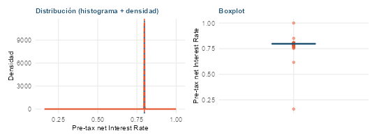

El histograma de **Pre-tax net Interest Rate** muestra un marcado sesgo a la izquierda (asimetría negativa), con una media de **0.7973** y una mediana de **0.7975**. La curtosis observada de **3772.15** indica la concentración de observaciones alrededor de la zona central, con posibles valores atípicos en las colas. Esta morfología sugiere una alta homogeneidad en el grueso de las empresas analizadas, con comportamientos extremos puntuales a monitorear en el preprocesamiento.

#### After-tax net Interest Rate

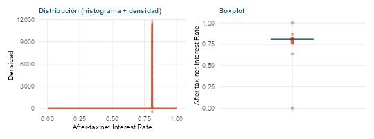

El histograma de **After-tax net Interest Rate** muestra un marcado sesgo a la izquierda (asimetría negativa), con una media de **0.8092** y una mediana de **0.8094**. La curtosis observada de **4356.85** indica la concentración de observaciones alrededor de la zona central, con posibles valores atípicos en las colas. Esta morfología sugiere una alta homogeneidad en el grueso de las empresas analizadas, con comportamientos extremos puntuales a monitorear en el preprocesamiento.

#### Non-industry income and expenditure/revenue

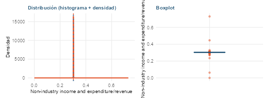

El histograma de **Non-industry income and expenditure/revenue** muestra un marcado sesgo a la derecha (asimetría positiva), con una media de **0.3035** y una mediana de **0.3035**. La curtosis observada de **1881.14** indica la concentración de observaciones alrededor de la zona central, con posibles valores atípicos en las colas. Esta morfología sugiere una alta homogeneidad en el grueso de las empresas analizadas, con comportamientos extremos puntuales a monitorear en el preprocesamiento.

#### Continuous interest rate (after tax)

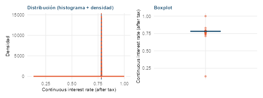

El histograma de **Continuous interest rate (after tax)** muestra un marcado sesgo a la izquierda (asimetría negativa), con una media de **0.7815** y una mediana de **0.7816**. La curtosis observada de **4160.36** indica la concentración de observaciones alrededor de la zona central, con posibles valores atípicos en las colas. Esta morfología sugiere una alta homogeneidad en el grueso de las empresas analizadas, con comportamientos extremos puntuales a monitorear en el preprocesamiento.

#### Operating Expense Rate

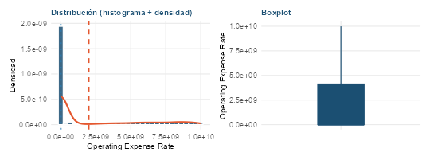

El histograma de **Operating Expense Rate** muestra un marcado sesgo a la derecha (asimetría positiva), con una media de **2013090624.6337** y una mediana de **0.0003**. La curtosis observada de **-0.11** indica la concentración de observaciones alrededor de la zona central, con posibles valores atípicos en las colas. Esta morfología sugiere una alta homogeneidad en el grueso de las empresas analizadas, con comportamientos extremos puntuales a monitorear en el preprocesamiento.

#### Research and development expense rate

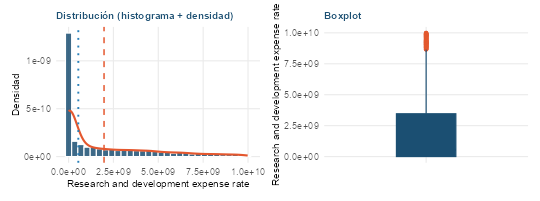

El histograma de **Research and development expense rate** muestra un marcado sesgo a la derecha (asimetría positiva), con una media de **1977042778.5925** y una mediana de **543000000.0000**. La curtosis observada de **0.55** indica la concentración de observaciones alrededor de la zona central, con posibles valores atípicos en las colas. Esta morfología sugiere una alta homogeneidad en el grueso de las empresas analizadas, con comportamientos extremos puntuales a monitorear en el preprocesamiento.

#### Cash flow rate

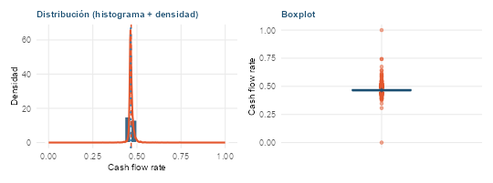

El histograma de **Cash flow rate** muestra un marcado sesgo a la derecha (asimetría positiva), con una media de **0.4675** y una mediana de **0.4651**. La curtosis observada de **262.45** indica la concentración de observaciones alrededor de la zona central, con posibles valores atípicos en las colas. Esta morfología sugiere una alta homogeneidad en el grueso de las empresas analizadas, con comportamientos extremos puntuales a monitorear en el preprocesamiento.

#### Interest-bearing debt interest rate

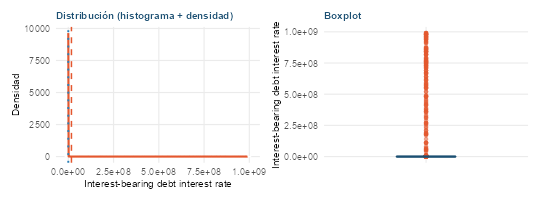

El histograma de **Interest-bearing debt interest rate** muestra un marcado sesgo a la derecha (asimetría positiva), con una media de **17396444.2825** y una mediana de **0.0003**. La curtosis observada de **47.35** indica la concentración de observaciones alrededor de la zona central, con posibles valores atípicos en las colas. Esta morfología sugiere una alta homogeneidad en el grueso de las empresas analizadas, con comportamientos extremos puntuales a monitorear en el preprocesamiento.

#### Tax rate (A)

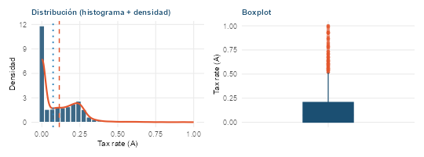

El histograma de **Tax rate (A)** muestra un marcado sesgo a la derecha (asimetría positiva), con una media de **0.1150** y una mediana de **0.0742**. La curtosis observada de **5.87** indica la concentración de observaciones alrededor de la zona central, con posibles valores atípicos en las colas. Esta morfología sugiere una alta homogeneidad en el grueso de las empresas analizadas, con comportamientos extremos puntuales a monitorear en el preprocesamiento.

#### Net Value Per Share (B)

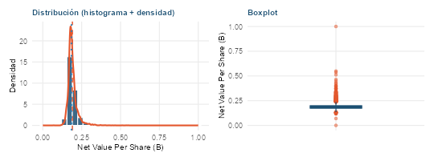

El histograma de **Net Value Per Share (B)** muestra un marcado sesgo a la derecha (asimetría positiva), con una media de **0.1902** y una mediana de **0.1842**. La curtosis observada de **79.43** indica la concentración de observaciones alrededor de la zona central, con posibles valores atípicos en las colas. Esta morfología sugiere una alta homogeneidad en el grueso de las empresas analizadas, con comportamientos extremos puntuales a monitorear en el preprocesamiento.

#### Net Value Per Share (A)

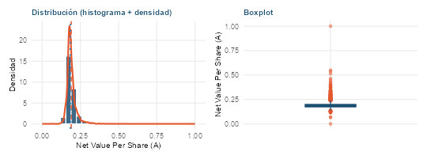

El histograma de **Net Value Per Share (A)** muestra un marcado sesgo a la derecha (asimetría positiva), con una media de **0.1902** y una mediana de **0.1842**. La curtosis observada de **78.56** indica la concentración de observaciones alrededor de la zona central, con posibles valores atípicos en las colas. Esta morfología sugiere una alta homogeneidad en el grueso de las empresas analizadas, con comportamientos extremos puntuales a monitorear en el preprocesamiento.

#### Net Value Per Share (C)

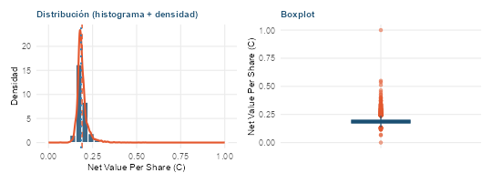

El histograma de **Net Value Per Share (C)** muestra un marcado sesgo a la derecha (asimetría positiva), con una media de **0.1903** y una mediana de **0.1843**. La curtosis observada de **78.47** indica la concentración de observaciones alrededor de la zona central, con posibles valores atípicos en las colas. Esta morfología sugiere una alta homogeneidad en el grueso de las empresas analizadas, con comportamientos extremos puntuales a monitorear en el preprocesamiento.

#### Persistent EPS in the Last Four Seasons

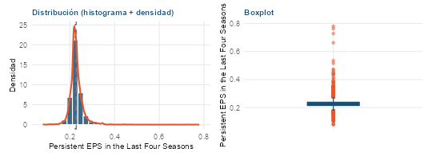

El histograma de **Persistent EPS in the Last Four Seasons** muestra un marcado sesgo a la derecha (asimetría positiva), con una media de **0.2287** y una mediana de **0.2246**. La curtosis observada de **52.87** indica la concentración de observaciones alrededor de la zona central, con posibles valores atípicos en las colas. Esta morfología sugiere una alta homogeneidad en el grueso de las empresas analizadas, con comportamientos extremos puntuales a monitorear en el preprocesamiento.

#### Cash Flow Per Share

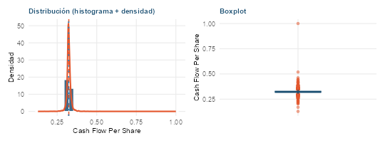

El histograma de **Cash Flow Per Share** muestra un marcado sesgo a la derecha (asimetría positiva), con una media de **0.3235** y una mediana de **0.3225**. La curtosis observada de **433.50** indica la concentración de observaciones alrededor de la zona central, con posibles valores atípicos en las colas. Esta morfología sugiere una alta homogeneidad en el grueso de las empresas analizadas, con comportamientos extremos puntuales a monitorear en el preprocesamiento.

#### Revenue Per Share (Yuan ¥)

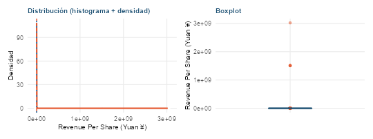

El histograma de **Revenue Per Share (Yuan ¥)** muestra un marcado sesgo a la derecha (asimetría positiva), con una media de **1660557.2236** y una mediana de **0.0273**. La curtosis observada de **1701.87** indica la concentración de observaciones alrededor de la zona central, con posibles valores atípicos en las colas. Esta morfología sugiere una alta homogeneidad en el grueso de las empresas analizadas, con comportamientos extremos puntuales a monitorear en el preprocesamiento.

#### Operating Profit Per Share (Yuan ¥)

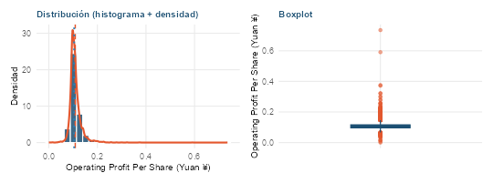

El histograma de **Operating Profit Per Share (Yuan ¥)** muestra un marcado sesgo a la derecha (asimetría positiva), con una media de **0.1089** y una mediana de **0.1043**. La curtosis observada de **92.73** indica la concentración de observaciones alrededor de la zona central, con posibles valores atípicos en las colas. Esta morfología sugiere una alta homogeneidad en el grueso de las empresas analizadas, con comportamientos extremos puntuales a monitorear en el preprocesamiento.

#### Per Share Net profit before tax (Yuan ¥)

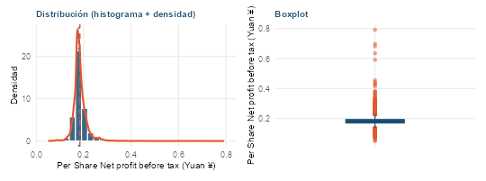

El histograma de **Per Share Net profit before tax (Yuan ¥)** muestra un marcado sesgo a la derecha (asimetría positiva), con una media de **0.1842** y una mediana de **0.1798**. La curtosis observada de **65.71** indica la concentración de observaciones alrededor de la zona central, con posibles valores atípicos en las colas. Esta morfología sugiere una alta homogeneidad en el grueso de las empresas analizadas, con comportamientos extremos puntuales a monitorear en el preprocesamiento.

#### Realized Sales Gross Profit Growth Rate

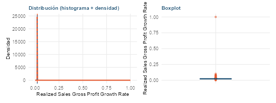

El histograma de **Realized Sales Gross Profit Growth Rate** muestra un marcado sesgo a la derecha (asimetría positiva), con una media de **0.0225** y una mediana de **0.0221**. La curtosis observada de **5053.61** indica la concentración de observaciones alrededor de la zona central, con posibles valores atípicos en las colas. Esta morfología sugiere una alta homogeneidad en el grueso de las empresas analizadas, con comportamientos extremos puntuales a monitorear en el preprocesamiento.

#### Operating Profit Growth Rate

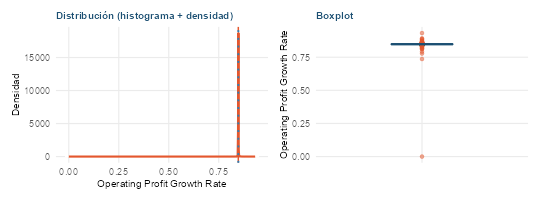

El histograma de **Operating Profit Growth Rate** muestra un marcado sesgo a la izquierda (asimetría negativa), con una media de **0.8479** y una mediana de **0.8480**. La curtosis observada de **4836.49** indica la concentración de observaciones alrededor de la zona central, con posibles valores atípicos en las colas. Esta morfología sugiere una alta homogeneidad en el grueso de las empresas analizadas, con comportamientos extremos puntuales a monitorear en el preprocesamiento.

#### After-tax Net Profit Growth Rate

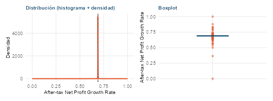

El histograma de **After-tax Net Profit Growth Rate** muestra un marcado sesgo a la izquierda (asimetría negativa), con una media de **0.6892** y una mediana de **0.6894**. La curtosis observada de **1438.63** indica la concentración de observaciones alrededor de la zona central, con posibles valores atípicos en las colas. Esta morfología sugiere una alta homogeneidad en el grueso de las empresas analizadas, con comportamientos extremos puntuales a monitorear en el preprocesamiento.

#### Regular Net Profit Growth Rate

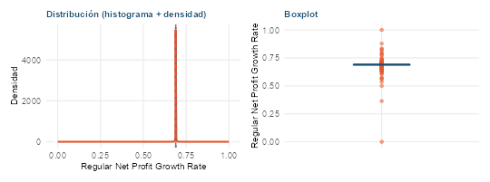

El histograma de **Regular Net Profit Growth Rate** muestra un marcado sesgo a la izquierda (asimetría negativa), con una media de **0.6892** y una mediana de **0.6894**. La curtosis observada de **1422.02** indica la concentración de observaciones alrededor de la zona central, con posibles valores atípicos en las colas. Esta morfología sugiere una alta homogeneidad en el grueso de las empresas analizadas, con comportamientos extremos puntuales a monitorear en el preprocesamiento.

#### Continuous Net Profit Growth Rate

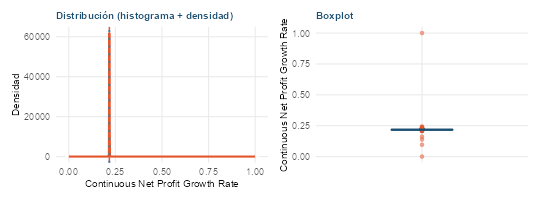

El histograma de **Continuous Net Profit Growth Rate** muestra un marcado sesgo a la derecha (asimetría positiva), con una media de **0.2177** y una mediana de **0.2176**. La curtosis observada de **4358.92** indica la concentración de observaciones alrededor de la zona central, con posibles valores atípicos en las colas. Esta morfología sugiere una alta homogeneidad en el grueso de las empresas analizadas, con comportamientos extremos puntuales a monitorear en el preprocesamiento.

#### Total Asset Growth Rate

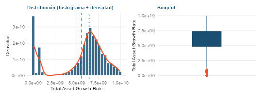

El histograma de **Total Asset Growth Rate** muestra un marcado sesgo a la izquierda (asimetría negativa), con una media de **5528156378.2993** y una mediana de **6420000000.0000**. La curtosis observada de **-0.39** indica la concentración de observaciones alrededor de la zona central, con posibles valores atípicos en las colas. Esta morfología sugiere una alta homogeneidad en el grueso de las empresas analizadas, con comportamientos extremos puntuales a monitorear en el preprocesamiento.

#### Net Value Growth Rate

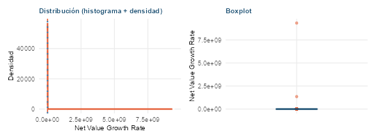

El histograma de **Net Value Growth Rate** muestra un marcado sesgo a la derecha (asimetría positiva), con una media de **1957478.0066** y una mediana de **0.0005**. La curtosis observada de **5236.67** indica la concentración de observaciones alrededor de la zona central, con posibles valores atípicos en las colas. Esta morfología sugiere una alta homogeneidad en el grueso de las empresas analizadas, con comportamientos extremos puntuales a monitorear en el preprocesamiento.

#### Total Asset Return Growth Rate Ratio

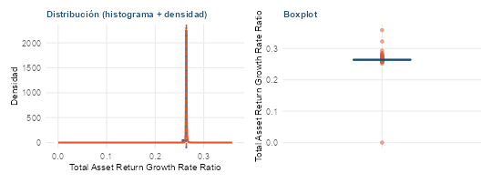

El histograma de **Total Asset Return Growth Rate Ratio** muestra un marcado sesgo a la izquierda (asimetría negativa), con una media de **0.2641** y una mediana de **0.2641**. La curtosis observada de **3341.97** indica la concentración de observaciones alrededor de la zona central, con posibles valores atípicos en las colas. Esta morfología sugiere una alta homogeneidad en el grueso de las empresas analizadas, con comportamientos extremos puntuales a monitorear en el preprocesamiento.